# Codex at BYU-I

Setup guide

BYU-Idaho

[figure not shown]

**Open the slides on your computer**shortie.fyi/ai-codex

## The setup path

Get from a BYU-I account to a working Codex extension in VS Code.

**Four checkpoints:** account access · workspace choice · Codex install · VS Code connection

[figure not shown]

bit.ly/4xgqTCg

Open this presentation on your computer.

## BYU-I ChatGPT access

Navigate to this URL:  
**byui.edu/ai/tools/chatgpt**

[figure not shown]

Start at the BYU-I ChatGPT page.

1. Select the BYU-I ChatGPT access link.
2. Choose **Church Educational System**.
3. Enter your BYU-I **username**@byui.edu. *(Be careful not to use your other email address instead of your username.)*

## The sign-in screen

[figure not shown]

Choose **Church Educational System**.

For this setup, choose CES so you enter through the BYU-I access path.

## Existing workspace choices

[figure not shown]

When ChatGPT adds you to the BYU-I Edu workspace, it may ask what to do with an existing workspace.

Choose the option that matches your situation:

- **Transfer existing chat history and GPTs** to merge into the Edu workspace
- **Export and delete existing chat history** to remove the existing workspace

## Download Codex from [openai.com/codex](https://openai.com/codex/)

Use the installer for your operating system, then open Codex and sign in with the BYU-I ChatGPT account you just connected.

**ChatGPT option:** access your ChatGPT conversations and account features.

**Codex option:** work with the coding agent to create, edit, and run code.

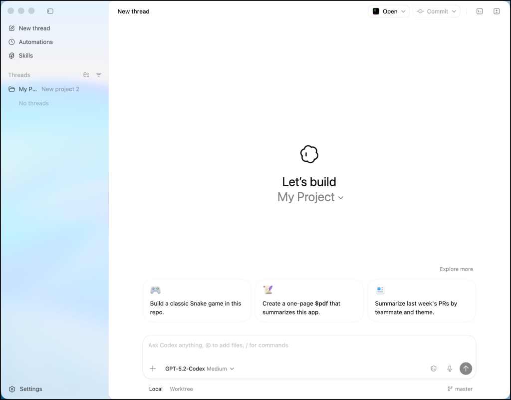

## VS Code connection

1. Install [Visual Studio Code](https://code.visualstudio.com/).
2. Install the [Codex extension](https://marketplace.visualstudio.com/items?itemName=OpenAI.chatgpt).
3. Open the VS Code command palette:

Mac: cmd + shift + p · Windows: ctrl + shift + p

4. Select **Codex: Open Codex Side Bar**.
5. Ignore or skip the guide and notifications that appear when the Codex sidebar opens.

If the Codex side bar opens, the VS Code connection is working.

[figure not shown]

[figure not shown]

Visual Studio Code + Codex

**Sign-in:** If you are already signed in to the Codex app, VS Code should sign you in automatically. Without the Codex app, you will need to sign in.

## Activity: Build a teaching tool

Work with a partner or two. Use VS Code and Codex to create a useful teaching tool for one of your classes.

Choose an idea or adapt one of these examples:

- Use the Quarto tool to make a small website where my slides for class can be hosted
- Create a small JavaScript app that can teach about the central limit theorem
- Create an interactive diagram that helps students understand determinants

Github is a very valuable tool to make these little tools published on the web.

## Ready for daily use

You are set up when you can:

- Open ChatGPT in the BYU-I Edu workspace
- Open the Codex app
- Open the Codex side bar inside VS Code

View the setup chat log